# LESSON 5: MATPLOTLIB INTRODUCTION - SOLUTION

[figure not shown]

## Homework

Note:

- We use the daily historical sales data from previous lecture in this homework. (Use this [link](https://drive.google.com/file/d/1R83MNlUShY55i3CzlXpMAMcxnEg4Hruw/view) to download this dataset)
- All figures must have title, label and legend.

### Exercise 1:

Randomly choose 3 shops, use `one line plot figure` to show the total turnover of them each month over 34 months (from January 2013 is 0, February 2013 is 1,..., October 2015 is 33.)

### Exercise 2:

Randomly choose 1 item, use `one combo figure with bar plot and line plot` to show the sales and the turnover of it over 34 months (from January 2013 is 0, February 2013 is 1,..., October 2015 is 33.)

### Exercise 3:

Randomly choose 3 items, use `one bar plot figure` to show the sales of them in 3 years 2013, 2014, and 2015.

### Exercise 4:

Randomly choose 1 shop, use `stack plot figure` to show the contribution of turnover of each item each month over 34 months (from January 2013 is 0, February 2013 is 1,..., October 2015 is 33.)

### Exercise 5:

Randomly choose 1 shop, use `pie plot figure` to show the contribution of turnover (in percent) of each item in 3 years 2013, 2014, and 2015. (1 pie plot figure for each year, use `subplots` to put all 3 figures together)

### Exercise 6:

Randomly choose 1 item, use `histogram figure` to show the distribution of sales of the item over 34 months (from January 2013 is 0, February 2013 is 1,..., October 2015 is 33.)

## Solution

```python
import matplotlib.pyplot as plt
import pandas as pd
import numpy as np
from tqdm import tqdm
```

```python
sales_df = pd.read_csv('../data/predict_future_sales/sales.csv')
sales_df
```

|  | date | date_block_num | shop_id | item_id | item_price | item_cnt_day |
| --- | --- | --- | --- | --- | --- | --- |
| 0 | 02.01.2013 | 0 | 59 | 22154 | 999.00 | 1.0 |
| 1 | 03.01.2013 | 0 | 25 | 2552 | 899.00 | 1.0 |
| 2 | 05.01.2013 | 0 | 25 | 2552 | 899.00 | -1.0 |
| 3 | 06.01.2013 | 0 | 25 | 2554 | 1709.05 | 1.0 |
| 4 | 15.01.2013 | 0 | 25 | 2555 | 1099.00 | 1.0 |
| ... | ... | ... | ... | ... | ... | ... |
| 2935844 | 10.10.2015 | 33 | 25 | 7409 | 299.00 | 1.0 |
| 2935845 | 09.10.2015 | 33 | 25 | 7460 | 299.00 | 1.0 |
| 2935846 | 14.10.2015 | 33 | 25 | 7459 | 349.00 | 1.0 |
| 2935847 | 22.10.2015 | 33 | 25 | 7440 | 299.00 | 1.0 |
| 2935848 | 03.10.2015 | 33 | 25 | 7460 | 299.00 | 1.0 |

2935849 rows × 6 columns

### Exercise 1:

Randomly choose 3 shops, use `one line plot figure` to show the total turnover of them each month over 34 months (from January 2013 is 0, February 2013 is 1,..., October 2015 is 33.)

```python
# Randomly choose 3 shops
np.random.seed(1)
random_shop_id = np.random.choice(sales_df.shop_id.unique(), size=3)
random_shop_id
```

```
array([52, 46,  4])
```

```python
# Get data of three random shop_id
random_shop_df = sales_df.loc[np.isin(sales_df.shop_id, random_shop_id)]
random_shop_df
```

|  | date | date_block_num | shop_id | item_id | item_price | item_cnt_day |
| --- | --- | --- | --- | --- | --- | --- |
| 30072 | 12.01.2013 | 0 | 4 | 5605 | 489.3 | 1.0 |
| 30073 | 03.01.2013 | 0 | 4 | 5587 | 199.0 | 1.0 |
| 30074 | 27.01.2013 | 0 | 4 | 5588 | 149.0 | 1.0 |
| 30075 | 21.01.2013 | 0 | 4 | 5613 | 6190.0 | 1.0 |
| 30076 | 08.01.2013 | 0 | 4 | 5627 | 2390.0 | 1.0 |
| ... | ... | ... | ... | ... | ... | ... |
| 2918122 | 28.10.2015 | 33 | 4 | 1586 | 5999.0 | 1.0 |
| 2918123 | 05.10.2015 | 33 | 4 | 1523 | 799.0 | 1.0 |
| 2918124 | 03.10.2015 | 33 | 4 | 1535 | 1999.0 | 1.0 |
| 2918125 | 01.10.2015 | 33 | 4 | 1325 | 449.0 | 1.0 |
| 2918126 | 13.10.2015 | 33 | 4 | 1788 | 999.0 | 1.0 |

148065 rows × 6 columns

```python
random_shop_df.date = random_shop_df.date.apply(lambda x: x[-7:])
random_shop_df
```

|  | date | date_block_num | shop_id | item_id | item_price | item_cnt_day |
| --- | --- | --- | --- | --- | --- | --- |
| 30072 | 01.2013 | 0 | 4 | 5605 | 489.3 | 1.0 |
| 30073 | 01.2013 | 0 | 4 | 5587 | 199.0 | 1.0 |
| 30074 | 01.2013 | 0 | 4 | 5588 | 149.0 | 1.0 |
| 30075 | 01.2013 | 0 | 4 | 5613 | 6190.0 | 1.0 |
| 30076 | 01.2013 | 0 | 4 | 5627 | 2390.0 | 1.0 |
| ... | ... | ... | ... | ... | ... | ... |
| 2918122 | 10.2015 | 33 | 4 | 1586 | 5999.0 | 1.0 |
| 2918123 | 10.2015 | 33 | 4 | 1523 | 799.0 | 1.0 |
| 2918124 | 10.2015 | 33 | 4 | 1535 | 1999.0 | 1.0 |
| 2918125 | 10.2015 | 33 | 4 | 1325 | 449.0 | 1.0 |
| 2918126 | 10.2015 | 33 | 4 | 1788 | 999.0 | 1.0 |

148065 rows × 6 columns

```python
def create_date_block_num(date):
    info = date.split('.')
    month = int(info[0])
    year = int(info[1])

    # 1 => 0, 2 => 1, 3 => 2
    new_date_block_num = month - 1
    new_date_block_num = new_date_block_num + (year - 2013) * 12
    return new_date_block_num
```

```python
random_shop_df['date_block_num_2'] = random_shop_df.date.apply(create_date_block_num)
random_shop_df
```

|  | date | date_block_num | shop_id | item_id | item_price | item_cnt_day | date_block_num_2 |
| --- | --- | --- | --- | --- | --- | --- | --- |
| 30072 | 01.2013 | 0 | 4 | 5605 | 489.3 | 1.0 | 0 |
| 30073 | 01.2013 | 0 | 4 | 5587 | 199.0 | 1.0 | 0 |
| 30074 | 01.2013 | 0 | 4 | 5588 | 149.0 | 1.0 | 0 |
| 30075 | 01.2013 | 0 | 4 | 5613 | 6190.0 | 1.0 | 0 |
| 30076 | 01.2013 | 0 | 4 | 5627 | 2390.0 | 1.0 | 0 |
| ... | ... | ... | ... | ... | ... | ... | ... |
| 2918122 | 10.2015 | 33 | 4 | 1586 | 5999.0 | 1.0 | 33 |
| 2918123 | 10.2015 | 33 | 4 | 1523 | 799.0 | 1.0 | 33 |
| 2918124 | 10.2015 | 33 | 4 | 1535 | 1999.0 | 1.0 | 33 |
| 2918125 | 10.2015 | 33 | 4 | 1325 | 449.0 | 1.0 | 33 |
| 2918126 | 10.2015 | 33 | 4 | 1788 | 999.0 | 1.0 | 33 |

148065 rows × 7 columns

```python
# Group sale dataframe by `shop_id` and `date_block_num`
sales_group_shop_df = random_shop_df.groupby(by=['shop_id', 'date_block_num'])
```

```python
def cal_turnover(grouped_df):
    '''
    Input: each grouped dataframe
    Output: Total turnover of each group
    '''
    price, num_items = grouped_df['item_price'], grouped_df['item_cnt_day']
    return np.sum(price * num_items)
```

```python
# Apply `cal_turnover` function for each group
# Reset index to create new df
# Rename calculated value column as `total_turnover`
turnover_shop_df = sales_group_shop_df.apply(cal_turnover).reset_index(name='total_turnover')
turnover_shop_df
```

|  | shop_id | date_block_num | total_turnover |
| --- | --- | --- | --- |
| 0 | 4 | 0 | 1433666.0 |
| 1 | 4 | 1 | 1532115.0 |
| 2 | 4 | 2 | 1415445.5 |
| 3 | 4 | 3 | 202647.0 |
| 4 | 4 | 4 | 917357.0 |
| ... | ... | ... | ... |
| 97 | 52 | 29 | 918807.0 |
| 98 | 52 | 30 | 771967.0 |
| 99 | 52 | 31 | 774314.0 |
| 100 | 52 | 32 | 1297043.0 |
| 101 | 52 | 33 | 943056.0 |

102 rows × 3 columns

```python
# Group by to get a list of `date_block_num` and `total_turnover`
turnover_shop_df = turnover_shop_df.groupby(by='shop_id').agg({
    'date_block_num': list,
    'total_turnover': list
}).reset_index()
turnover_shop_df
```

|  | shop_id | date_block_num | total_turnover |
| --- | --- | --- | --- |
| 0 | 4 | [0, 1, 2, 3, 4, 5, 6, 7, 8, 9, 10, 11, 12, 13,... | [1433666.0, 1532114.99999998, 1415445.49999999... |
| 1 | 46 | [0, 1, 2, 3, 4, 5, 6, 7, 8, 9, 10, 11, 12, 13,... | [2358347.999999995, 2021670.099999932, 2198033... |
| 2 | 52 | [0, 1, 2, 3, 4, 5, 6, 7, 8, 9, 10, 11, 12, 13,... | [1160182.999999999, 1174198.0300000492, 126084... |

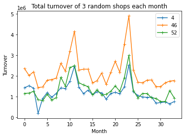

```python
# Plot the figure
for index, row in turnover_shop_df.iterrows():
    plt.plot(row.date_block_num, row.total_turnover, label=row.shop_id, marker='+')

plt.xlabel('Month')
plt.ylabel('Turnover')
plt.title('Total turnover of 3 random shops each month')
plt.legend()
plt.show()
```

### Exercise 2:

Randomly choose 1 item, use `one combo figure with bar plot and line plot` to show the sales and the turnover of it over 34 months (from January 2013 is 0, February 2013 is 1,..., October 2015 is 33.)

```python
# Randomly choose 1 item
np.random.seed(1)
random_item_id = np.random.choice(sales_df.item_id.unique(), size=1)
random_item_id
```

```
array([970])
```

```python
# Get data of the random item_id
random_item_df = sales_df.loc[sales_df.item_id == random_item_id[0]]
random_item_df
```

|  | date | date_block_num | shop_id | item_id | item_price | item_cnt_day |
| --- | --- | --- | --- | --- | --- | --- |
| 636 | 02.01.2013 | 0 | 25 | 970 | 279.0 | 1.0 |
| 2394 | 08.01.2013 | 0 | 24 | 970 | 279.0 | 1.0 |
| 2395 | 26.01.2013 | 0 | 24 | 970 | 279.0 | 1.0 |
| 10043 | 12.01.2013 | 0 | 19 | 970 | 279.0 | 1.0 |
| 13269 | 27.01.2013 | 0 | 21 | 970 | 279.0 | 1.0 |
| ... | ... | ... | ... | ... | ... | ... |
| 2890056 | 28.10.2015 | 33 | 35 | 970 | 331.0 | 1.0 |
| 2892229 | 03.10.2015 | 33 | 38 | 970 | 349.0 | 1.0 |
| 2902698 | 15.10.2015 | 33 | 49 | 970 | 349.0 | 1.0 |
| 2908977 | 17.10.2015 | 33 | 16 | 970 | 349.0 | 1.0 |
| 2930055 | 03.10.2015 | 33 | 25 | 970 | 349.0 | 1.0 |

568 rows × 6 columns

```python
# Group sale dataframe by `date_block_num`
sales_group_date_df = random_item_df.groupby(by=['date_block_num'])
sales_group_date_df
```

```
<pandas.core.groupby.generic.DataFrameGroupBy object at 0x7fe3882f9c10>
```

```python
# Use `agg` to calcuate number of item each date_block_num
sales_item_df = sales_group_date_df.agg({'item_cnt_day': sum}).reset_index()
sales_item_df
```

|  | date_block_num | item_cnt_day |
| --- | --- | --- |
| 0 | 0 | 14.0 |
| 1 | 1 | 6.0 |
| 2 | 2 | 27.0 |
| 3 | 3 | 21.0 |
| 4 | 4 | 27.0 |
| 5 | 5 | 30.0 |
| 6 | 6 | 22.0 |
| 7 | 7 | 5.0 |
| 8 | 8 | 9.0 |
| 9 | 9 | 1.0 |
| 10 | 11 | 1.0 |
| 11 | 14 | 2.0 |
| 12 | 15 | 39.0 |
| 13 | 16 | 43.0 |
| 14 | 17 | 32.0 |
| 15 | 18 | 35.0 |
| 16 | 19 | 30.0 |
| 17 | 20 | 21.0 |
| 18 | 21 | 20.0 |
| 19 | 22 | 18.0 |
| 20 | 23 | 30.0 |
| 21 | 24 | 17.0 |
| 22 | 25 | 17.0 |
| 23 | 26 | 28.0 |
| 24 | 27 | 18.0 |
| 25 | 28 | 11.0 |
| 26 | 29 | 14.0 |
| 27 | 30 | 10.0 |
| 28 | 31 | 9.0 |
| 29 | 32 | 8.0 |
| 30 | 33 | 5.0 |

```python
# Apply `cal_turnover` function for each group
# Reset index to create new df
# Rename calculated value column as `total_turnover`
turnover_item_df = sales_group_date_df.apply(cal_turnover).reset_index(name='total_turnover')
turnover_item_df
```

|  | date_block_num | total_turnover |
| --- | --- | --- |
| 0 | 0 | 3906.00 |
| 1 | 1 | 1556.00 |
| 2 | 2 | 7533.00 |
| 3 | 3 | 5859.00 |
| 4 | 4 | 7533.00 |
| 5 | 5 | 8370.00 |
| 6 | 6 | 6020.00 |
| 7 | 7 | 1395.00 |
| 8 | 8 | 2511.00 |
| 9 | 9 | 279.00 |
| 10 | 11 | 279.00 |
| 11 | 14 | 598.00 |
| 12 | 15 | 11661.00 |
| 13 | 16 | 12733.05 |
| 14 | 17 | 9568.00 |
| 15 | 18 | 10356.00 |
| 16 | 19 | 8970.00 |
| 17 | 20 | 6279.00 |
| 18 | 21 | 5871.00 |
| 19 | 22 | 5273.00 |
| 20 | 23 | 8909.80 |
| 21 | 24 | 5083.00 |
| 22 | 25 | 5313.00 |
| 23 | 26 | 9649.20 |
| 24 | 27 | 6282.00 |
| 25 | 28 | 3839.00 |
| 26 | 29 | 4886.00 |
| 27 | 30 | 3490.00 |
| 28 | 31 | 3141.00 |
| 29 | 32 | 2792.00 |
| 30 | 33 | 1727.00 |

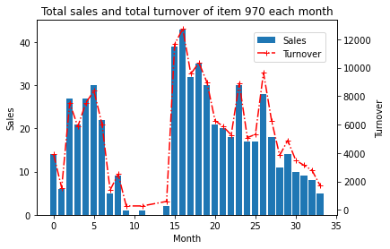

```python
# Plot the figure
fig, ax_1 = plt.subplots()
ax_1.bar(sales_item_df.date_block_num, sales_item_df.item_cnt_day, label='Sales')
ax_1.set_ylabel('Sales')
ax_1.set_xlabel('Month')

ax_2 = ax_1.twinx()
ax_2.plot(turnover_item_df.date_block_num, turnover_item_df.total_turnover, '+-.r', label='Turnover')
ax_2.set_ylabel('Turnover')

fig.legend(loc=(0.65, 0.75))
plt.title(f'Total sales and total turnover of item {random_item_id[0]} each month')
plt.show()
```

### Exercise 3:

Randomly choose 3 items, use `one bar plot figure` to show the sales of them in 3 years 2013, 2014, and 2015.

```python
# Randomly choose 3 items
np.random.seed(0)
random_item_id = np.random.choice(sales_df.item_id.unique(), size=3)
random_item_id
```

```
array([11484, 15044, 16718])
```

```python
# Process `date` to get the year
new_date_sales_df = sales_df.copy()
new_date_sales_df['date'] = new_date_sales_df.date.apply(lambda x: x.split('.')[-1])
```

```python
# Get data of the random item_ids
random_item_df = new_date_sales_df.loc[np.isin(new_date_sales_df.item_id, random_item_id)]
random_item_df
```

|  | date | date_block_num | shop_id | item_id | item_price | item_cnt_day |
| --- | --- | --- | --- | --- | --- | --- |
| 6770 | 2013 | 0 | 25 | 11484 | 149.0 | 1.0 |
| 6771 | 2013 | 0 | 25 | 11484 | 149.0 | 1.0 |
| 10734 | 2013 | 0 | 19 | 11484 | 149.0 | 2.0 |
| 10735 | 2013 | 0 | 19 | 11484 | 149.0 | 1.0 |
| 16190 | 2013 | 0 | 28 | 11484 | 149.0 | 1.0 |
| ... | ... | ... | ... | ... | ... | ... |
| 2837562 | 2015 | 32 | 38 | 15044 | 298.0 | 1.0 |
| 2843132 | 2015 | 32 | 57 | 11484 | 99.0 | 1.0 |
| 2847676 | 2015 | 32 | 51 | 11484 | 90.0 | 1.0 |
| 2868766 | 2015 | 32 | 31 | 11484 | 99.0 | 1.0 |
| 2899778 | 2015 | 33 | 57 | 15044 | 248.0 | 1.0 |

4006 rows × 6 columns

```python
# Group by `date` and `item_id` to get item_count each year
grouped_item_df = random_item_df.groupby(by=['date', 'item_id']).agg({'item_cnt_day': sum})
grouped_item_df = grouped_item_df.reset_index()
grouped_item_df
```

|  | date | item_id | item_cnt_day |
| --- | --- | --- | --- |
| 0 | 2013 | 11484 | 653.0 |
| 1 | 2013 | 15044 | 4988.0 |
| 2 | 2013 | 16718 | 1.0 |
| 3 | 2014 | 11484 | 173.0 |
| 4 | 2014 | 15044 | 661.0 |
| 5 | 2015 | 11484 | 99.0 |
| 6 | 2015 | 15044 | 75.0 |

```python
def fill_missing_value(df, year_list):
    for year in year_list:
        if len(df[df.date == year]) == 0:
            data={
                'date': year,
                'item_id': df.item_id.values[0],
                'item_cnt_day': 0
            }
            df = df.append(data, ignore_index=True)
    df = df.sort_values(by='date')
    return df
```

```
   date  item_id  item_cnt_day
0  2013    11484         653.0
3  2014    11484         173.0
5  2015    11484          99.0
   date  item_id  item_cnt_day
1  2013    15044        4988.0
4  2014    15044         661.0
6  2015    15044          75.0
   date  item_id  item_cnt_day
0  2013    16718           1.0
1  2014    16718           0.0
2  2015    16718           0.0
```

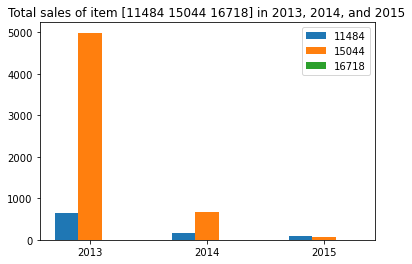

```python
year_list = ['2013', '2014', '2015']
x_axis = np.arange(len(year_list)).astype(float)

for index, item_id in enumerate(random_item_id):
    df = grouped_item_df[grouped_item_df.item_id == item_id]
    df = fill_missing_value(df, year_list)
    print(df)

    plt.bar(x_axis, df.item_cnt_day, label=item_id, width=0.2)
    final_x_axis = (x_axis + np.arange(len(year_list))) / 2
    x_axis += 0.2

plt.xticks(final_x_axis, year_list)
plt.legend()
plt.title(f'Total sales of item {random_item_id} in 2013, 2014, and 2015')
plt.show()
```

### Exercise 4:

Randomly choose 1 shop, use `stack plot figure` to show the contribution of turnover of each item each month over 34 months (from January 2013 is 0, February 2013 is 1,..., October 2015 is 33.)

```python
# Randomly choose 1 shop
np.random.seed(2)
random_shop_id = np.random.choice(sales_df.shop_id.unique(), size=1)
random_shop_id
```

```
array([38])
```

```python
# Get data of random shop_id
random_shop_df = new_date_sales_df.loc[np.isin(new_date_sales_df.shop_id, random_shop_id)]
random_shop_df
```

|  | date | date_block_num | shop_id | item_id | item_price | item_cnt_day |
| --- | --- | --- | --- | --- | --- | --- |
| 102088 | 2013 | 0 | 38 | 22154 | 999.0 | 1.0 |
| 102089 | 2013 | 0 | 38 | 22151 | 399.0 | 1.0 |
| 102090 | 2013 | 0 | 38 | 22134 | 399.0 | 1.0 |
| 102091 | 2013 | 0 | 38 | 22134 | 399.0 | 1.0 |
| 102092 | 2013 | 0 | 38 | 22134 | 399.0 | 1.0 |
| ... | ... | ... | ... | ... | ... | ... |
| 2893353 | 2015 | 33 | 38 | 20367 | 1899.0 | 1.0 |
| 2893354 | 2015 | 33 | 38 | 20393 | 1999.0 | 1.0 |
| 2893355 | 2015 | 33 | 38 | 20405 | 2399.0 | 1.0 |
| 2893356 | 2015 | 33 | 38 | 20428 | 1599.0 | 1.0 |
| 2893357 | 2015 | 33 | 38 | 20448 | 299.0 | 1.0 |

46013 rows × 6 columns

```python
# Group sale dataframe by `item_id` and `date_block_num`
sales_group_shop_df = random_shop_df.groupby(by=['item_id', 'date_block_num'])
# Apply `cal_turnover` function for each group
# Reset index to create new df
# Rename calculated value column as `total_turnover`
sales_group_shop_df = sales_group_shop_df.apply(cal_turnover).reset_index(name='total_turnover')
sales_group_shop_df
```

|  | item_id | date_block_num | total_turnover |
| --- | --- | --- | --- |
| 0 | 28 | 2 | 398.0 |
| 1 | 30 | 1 | 3192.0 |
| 2 | 30 | 2 | 798.0 |
| 3 | 30 | 7 | 399.0 |
| 4 | 30 | 11 | 169.0 |
| ... | ... | ... | ... |
| 26104 | 22167 | 18 | 299.0 |
| 26105 | 22167 | 19 | 299.0 |
| 26106 | 22167 | 21 | 598.0 |
| 26107 | 22167 | 27 | 598.0 |
| 26108 | 22167 | 28 | 299.0 |

26109 rows × 3 columns

```python
# Prepare the unique item_id of this shop
unique_item_id = sales_group_shop_df.item_id.unique()
len(unique_item_id)
```

```
7356
```

```python
# Prepare data to plot
total_turnover_list, item_id_list = [], []

for item_id in tqdm(unique_item_id):
    item_df = sales_group_shop_df[sales_group_shop_df.item_id == item_id]

#     Check item_id which was sold in all 34 months
    if len(item_df) < 34:
#         Skip these item_id
        continue

    total_turnover_list.append(item_df.total_turnover.values)
    item_id_list.append(str(item_id))
```

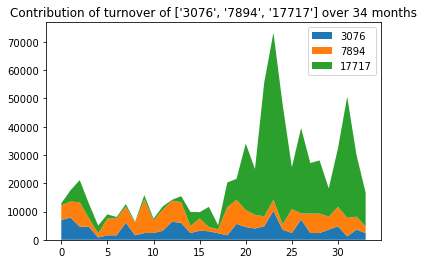

```python
# Plot the figure
total_turnover_np = np.array(total_turnover_list, dtype=np.float32)
index = np.arange(34)
plt.stackplot(index, total_turnover_np, labels=item_id_list)
plt.legend()
plt.title(f'Contribution of turnover of {item_id_list} over 34 months')
plt.show()
```

### Exercise 5:

Randomly choose 1 shop, use `pie plot figure` to show the contribution of turnover (in percent) of each item in 3 years 2013, 2014, and 2015. (1 pie plot figure for each year, use `subplots` to put all 3 figures together)

```python
# Calculate turnorver in year
total_turnover_list_by_year = []
for total_turnover in total_turnover_list:
    total_turnover_2013 = np.sum(total_turnover[:12])
    total_turnover_2014 = np.sum(total_turnover[12:24])
    total_turnover_2015 = np.sum(total_turnover[24:])
    total_turnover_list_by_year.append(
        np.array([total_turnover_2013, total_turnover_2014, total_turnover_2015]))

total_turnover_list_by_year = np.array(total_turnover_list_by_year)
```

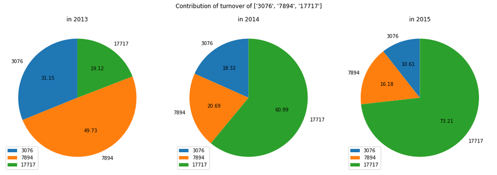

```python
# Plot the figure
fig, ax = plt.subplots(1, 3, figsize=(15, 5))
for index, year in enumerate(year_list):
    ax[index].pie(total_turnover_list_by_year[:, index], labels=item_id_list, startangle=90, autopct='%.2f')
    ax[index].legend(loc='lower left')
    ax[index].set_title(f'in {year}')

plt.suptitle(f'Contribution of turnover of {item_id_list}', horizontalalignment='center', verticalalignment='bottom')
plt.tight_layout()
plt.show()
```

### Exercise 6:

Randomly choose 1 item, use `histogram figure` to show the distribution of sales of the item over 34 months (from January 2013 is 0, February 2013 is 1,..., October 2015 is 33.)

```python
np.random.seed(0)
random_item_id = np.random.choice(sales_df.item_id.unique(), size=1)
random_item_id
```

```
array([11484])
```

```python
item_df = sales_df.loc[sales_df.item_id == random_item_id[0]]
item_count = item_df.groupby(by='date').agg({'item_cnt_day': sum}).reset_index()
```

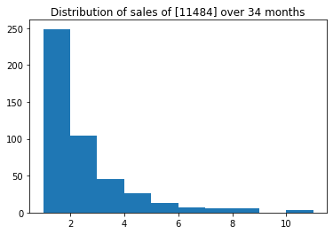

```python
plt.hist(item_count.item_cnt_day)
plt.title(f'Distribution of sales of {random_item_id} over 34 months')
plt.show()
```